# Health and Economic Effects of Storms in the United States

Reproducible Research Assignment 2

J.C. Gaukel

April 26, 2015

## Synopsis

The purpose of this analysis is to help answer the following questions:

- Across the United States, which types of events (as indicated in the EVTYPE variable) are most harmful with respect to population health?
- Across the United States, which types of events have the greatest economic consequences?

This analysis uses storm data gathered from 1950 through November 2011. The data is coerced (as much as is practical) into the weather categories defined by the National Weather Service.

## Data Processing

The data used can be downloaded from https://d396qusza40orc.cloudfront.net/repdata%2Fdata%2FStormData.csv.bz2. Additional information can be gathered from:

- [National Weather Service Storm Data Documentation](https://d396qusza40orc.cloudfront.net/repdata%2Fpeer2_doc%2Fpd01016005curr.pdf)
- [National Climatic Data Center Storm Events FAQ](https://d396qusza40orc.cloudfront.net/repdata%2Fpeer2_doc%2FNCDC%20Storm%20Events-FAQ%20Page.pdf)

The following code will check to see if the file exists and if it has the correct check sum. If it doesn’t then it will download it. It then checks for the extracted file and it’s check sum. If it doesn’t exist or the check sum doesn’t match, then it extracts it. Then it loads the data.

```r
# loading ALL required libraries
library(tools)
library(ggplot2)
library(scales)
library(plyr)
library(stringr)
library(R.utils)
library(sqldf)
```

```r
# file information (downloaded on 4/21/2015 3:20 PM CDT)
filelink <- "https://d396qusza40orc.cloudfront.net/repdata%2Fdata%2FStormData.csv.bz2"
filename <- "repdata_data_StormData.csv.bz2"
filechecksum <- "df4aa61fff89427db6b7f7b1113b5553"
extractedfile <- "Extracted Data/repdata_data_StormData.csv"
extractedfilechecksum <- "33ab0bd27d935eeefef0dd7300f800af"

# check to see if file is missing or checksum has changed
if (!file.exists(filename)|md5sum(filename) != filechecksum) {
        # download the file.
        download.file(filelink, filename)
        }

# check to see if the extracted file exists or the checksum doesn't match
if (!file.exists(extractedfile) | md5sum(extractedfile) != extractedfilechecksum) {
        # extract file
        bunzip2(filename = filename, destname = extractedfile)
        }

# read in data file
sd <- read.csv(extractedfile)
```

The following function is used to normalize the storm event types as much as is practical. (Event types that are either non-impactful or don’t contribute significantly to the impact are grouped together under “UNKNOWN/OTHER”. Running the function the the debug option set to TRUE will leave them ungrouped.)

```r
# functions to normalize event types
clean.EVTYPE <- function(x, debug=FALSE){
        library(stringr)
        # these are the standard categories as defined by the National Weather Service
        valid.EVTYPE <- c("ASTRONOMICAL LOW TIDE",
                          "AVALANCHE",
                          "BLIZZARD",
                          "COASTAL FLOOD",
                          "COLD/WIND CHILL",
                          "DEBRIS FLOW",
                          "DENSE FOG",
                          "DENSE SMOKE",
                          "DROUGHT",
                          "DUST DEVIL",
                          "DUST STORM",
                          "EXCESSIVE HEAT",
                          "EXTREME COLD/WIND CHILL",
                          "FLASH FLOOD",
                          "FLOOD",
                          "FROST/FREEZE",
                          "FUNNEL CLOUD",
                          "FREEZING FOG",
                          "HAIL",
                          "HEAT",
                          "HEAVY RAIN",
                          "HEAVY SNOW",
                          "HIGH SURF",
                          "HIGH WIND",
                          "HURRICANE (TYPHOON)",
                          "ICE STORM",
                          "LAKE-EFFECT SNOW",
                          "LAKESHORE FLOOD",
                          "LIGHTNING",
                          "MARINE HAIL",
                          "MARINE HIGH WIND",
                          "MARINE STRONG WIND",
                          "MARINE THUNDERSTORM WIND",
                          "RIP CURRENT",
                          "SEICHE",
                          "SLEET",
                          "STORM SURGE/TIDE",
                          "STRONG WIND",
                          "THUNDERSTORM WIND",
                          "TORNADO",
                          "TROPICAL DEPRESSION",
                          "TROPICAL STORM",
                          "TSUNAMI",
                          "VOLCANIC ASH",
                          "WATERSPOUT",
                          "WILDFIRE",
                          "WINTER STORM",
                          "WINTER WEATHER")

        # remove spaces before and after
        new.EVTYPE <- str_trim(x, side="both")

        # change to upper case
        new.EVTYPE <- toupper(new.EVTYPE)

        # remove misc punctuation
        new.EVTYPE <- sub("\\.$", "", new.EVTYPE)
        new.EVTYPE <- sub(";$", "", new.EVTYPE)
        new.EVTYPE <- sub("\\(", " ", new.EVTYPE) # note: this will break "HURRICANE (TYPHOON)", but we fix it later
        new.EVTYPE <- sub(")$", "", new.EVTYPE)   # note: this will break "HURRICANE (TYPHOON)", but we fix it later

        # remove all double spaces within value
        while(length(grep("  ", new.EVTYPE)) > 0){new.EVTYPE <- sub("  ", " ", new.EVTYPE)}

        # remove spaces before and after slashes and stanardize them
        new.EVTYPE <- sub("-", "/", new.EVTYPE)
        new.EVTYPE <- sub(";", "/", new.EVTYPE)
        new.EVTYPE <- sub("\\\\", "/", new.EVTYPE)
        new.EVTYPE <- sub("/ ", "/", new.EVTYPE)
        new.EVTYPE <- sub(" /", "/", new.EVTYPE)

        # replace abbreviations
        new.EVTYPE <- sub("TSTM ", "THUNDERSTORM ", new.EVTYPE)
        new.EVTYPE <- sub("SML ", "SMALL ", new.EVTYPE)
        new.EVTYPE <- sub("FLD", "FLOOD", new.EVTYPE)

        # fix typos
        new.EVTYPE <- sub("^AVALANCE$", "AVALANCHE", new.EVTYPE)
        new.EVTYPE <- sub("THUNDERTORM", "THUNDERSTORM", new.EVTYPE)
        new.EVTYPE <- sub("^THUNDERSTORMW$", "THUNDERSTORM", new.EVTYPE)
        new.EVTYPE <- sub("TUNDERSTORM", "THUNDERSTORM", new.EVTYPE)
        new.EVTYPE <- sub("THUNERSTORM", "THUNDERSTORM", new.EVTYPE)
        new.EVTYPE <- sub("THUNDERSTROM", "THUNDERSTORM", new.EVTYPE)
        new.EVTYPE <- sub("THUNDERESTORM", "THUNDERSTORM", new.EVTYPE)
        new.EVTYPE <- sub("THUNDEERSTORM", "THUNDERSTORM", new.EVTYPE)
        new.EVTYPE <- sub("THUDERSTORM", "THUNDERSTORM", new.EVTYPE)
        new.EVTYPE <- sub("WINS", "WINDS", new.EVTYPE)
        new.EVTYPE <- sub("^LIGHTING$", "LIGHTNING", new.EVTYPE)
        new.EVTYPE <- sub("^TORNDAO", "TORNDAO", new.EVTYPE)

        # remove descriptors
        new.EVTYPE <- sub("^MAJOR ", "", new.EVTYPE)
        new.EVTYPE <- sub("^MINOR ", "", new.EVTYPE)
        new.EVTYPE <- sub("^SEVERE ", "", new.EVTYPE)
        new.EVTYPE <- sub("^SMALL ", "", new.EVTYPE)
        new.EVTYPE <- sub("^URBAN ", "", new.EVTYPE)
        new.EVTYPE <- sub("^URBAN/SMALL ", "", new.EVTYPE)
        new.EVTYPE <- sub("^STREAM ", "", new.EVTYPE)

        new.EVTYPE <- sub("^EROSION/", "", new.EVTYPE)

        # remove plurals and verbs
        new.EVTYPE <- sub("CURRENTS$", "CURRENT", new.EVTYPE)
        new.EVTYPE <- sub("WINDS$", "WIND", new.EVTYPE)
        new.EVTYPE <- sub("STORMS", "STORM", new.EVTYPE)
        new.EVTYPE <- sub("FLOODING", "FLOOD", new.EVTYPE)
        new.EVTYPE <- sub("FLOODS", "FLOOD", new.EVTYPE)
        new.EVTYPE <- sub("RAINS", "RAIN", new.EVTYPE)
        new.EVTYPE <- sub("WINDS", "WIND", new.EVTYPE)
        new.EVTYPE <- sub("FIRES", "FIRE", new.EVTYPE)
        new.EVTYPE <- sub("TORNADOES", "TORNADO", new.EVTYPE)

        # coerce into standard event types
        ## BLIZZARD
        new.EVTYPE <- sub("^HEAVY SNOW AND HIGH WINDS$", "BLIZZARD", new.EVTYPE)

        ## COASTAL FLOOD
        new.EVTYPE <- sub("^COASTAL FLOOD.*$", "COASTAL FLOOD", new.EVTYPE)

        ## COLD/WIND CHILL
        new.EVTYPE <- sub("^COLD$", "COLD/WIND CHILL", new.EVTYPE)

        ## DENSE FOG
        new.EVTYPE <- sub("^FOG$", "DENSE FOG", new.EVTYPE)

        ## EXCESSIVE HEAT
        new.EVTYPE <- sub("^EXTREME HEAT$", "EXCESSIVE HEAT", new.EVTYPE)

        ## EXTREME COLD/WIND CHILL
        new.EVTYPE <- sub("^EXTREME COLD.*$", "EXTREME COLD/WIND CHILL", new.EVTYPE)
        new.EVTYPE <- sub("^RECORD COLD.*$", "EXTREME COLD/WIND CHILL", new.EVTYPE)

        ## FLASH FLOOD
        new.EVTYPE <- sub("^FLASH FLOOD.*$", "FLASH FLOOD", new.EVTYPE)

        ## FLOOD
        new.EVTYPE <- sub("^RIVER FLOOD$", "FLOOD", new.EVTYPE)
        new.EVTYPE <- sub("^SNOWMELT FLOOD$", "FLOOD", new.EVTYPE)
        new.EVTYPE <- sub("^ICE JAM FLOOD$", "FLOOD", new.EVTYPE)
        new.EVTYPE <- sub("^FLOOD.*$", "FLOOD", new.EVTYPE)

        ## HAIL
        new.EVTYPE <- sub("^HAIL.*$", "HAIL", new.EVTYPE)

        ## HEAT
        new.EVTYPE <- sub("^HEAT WAVE$", "HEAT", new.EVTYPE)

        ## HEAVY RAIN
        new.EVTYPE <- sub("^HEAVY RAIN.*$", "HEAVY RAIN", new.EVTYPE)
        new.EVTYPE <- sub("^RAIN$", "HEAVY RAIN", new.EVTYPE)

        ## HEAVY SNOW
        new.EVTYPE <- sub("^HEAVY SNOW.*$", "HEAVY SNOW", new.EVTYPE)
        new.EVTYPE <- sub("^HEAVY SNOW.*$", "HEAVY SNOW", new.EVTYPE)
        new.EVTYPE <- sub("^SNOW( |/).*$", "WINTER WEATHER", new.EVTYPE)
        new.EVTYPE <- sub("^SNOW( |/).*$", "WINTER WEATHER", new.EVTYPE)
        new.EVTYPE <- sub("^SNOW$", "WINTER WEATHER", new.EVTYPE)

        ## HIGH SURF
        new.EVTYPE <- sub("^HEAVY SURF/HIGH SURF$", "HIGH SURF", new.EVTYPE)
        new.EVTYPE <- sub("^HEAVY SURF$", "HIGH SURF", new.EVTYPE)

        ## HIGH WIND
        new.EVTYPE <- sub("^HIGH WIND.*$", "HIGH WIND", new.EVTYPE)

        ## HURRICANE (TYPHOON)
        new.EVTYPE <- sub("^HURRICANE .*$", "HURRICANE (TYPHOON)", new.EVTYPE)
        new.EVTYPE <- sub("^HURRICANE/TYPHOON$", "HURRICANE (TYPHOON)", new.EVTYPE)
        new.EVTYPE <- sub("^HURRICANE$", "HURRICANE (TYPHOON)", new.EVTYPE)
        new.EVTYPE <- sub("^TYPHOON$", "HURRICANE (TYPHOON)", new.EVTYPE)

        ## ICE STORM
        new.EVTYPE <- sub("^ICE$", "ICE STORM", new.EVTYPE)

        ## LIGHTNING
        new.EVTYPE <- sub("^LIGHTNING.*$", "LIGHTNING", new.EVTYPE)

        ## STORM SURGE/TIDE
        new.EVTYPE <- sub("^STORM SURGE$", "STORM SURGE/TIDE", new.EVTYPE)

        ## STRONG WIND
        new.EVTYPE <- sub("^GUSTY WIND$", "STRONG WIND", new.EVTYPE)
        new.EVTYPE <- sub("^WIND$", "STRONG WIND", new.EVTYPE)

        ## THUNDERSTORM WIND
        new.EVTYPE <- sub("^THUNDERSTORM$", "THUNDERSTORM WIND", new.EVTYPE)
        new.EVTYPE <- sub("^THUNDERSTORM WIND.*$", "THUNDERSTORM WIND", new.EVTYPE)
        new.EVTYPE <- sub("^TSTMW$", "THUNDERSTORM WIND", new.EVTYPE)
        new.EVTYPE <- sub("^THUNDERSTORMWINDS$", "THUNDERSTORM WIND", new.EVTYPE)

        ## TORNADO
        new.EVTYPE <- sub("^WATERSPOUT/TORNADO$", "TORNADO", new.EVTYPE)
        new.EVTYPE <- sub("^TORNADO.*$", "TORNADO", new.EVTYPE)

        ## TROPICAL STORM
        new.EVTYPE <- sub("^TROPICAL STORM.*$", "TROPICAL STORM", new.EVTYPE)

        ## WILDFIRE
        new.EVTYPE <- sub("^WILD FIRE$", "WILDFIRE", new.EVTYPE)
        new.EVTYPE <- sub("^WILD/FOREST FIRE$", "WILDFIRE", new.EVTYPE)
        new.EVTYPE <- sub("^FOREST FIRE$", "WILDFIRE", new.EVTYPE)

        ## WINTER STORM
        new.EVTYPE <- sub("^WINTER STORM.*$", "WINTER STORM", new.EVTYPE)

        ## WINTER WEATHER
        new.EVTYPE <- sub("^WINTER WEATHER MIX$", "WINTER WEATHER", new.EVTYPE)
        new.EVTYPE <- sub("^WINTER WEATHER/MIX$", "WINTER WEATHER", new.EVTYPE)
        new.EVTYPE <- sub("^WINTRY MIX$", "WINTER WEATHER", new.EVTYPE)

        ## anything that isn't matched gets lumped together as "UNKNOWN/OTHER"
        if(!debug){
                missing.EVTYPE <- !(new.EVTYPE %in% valid.EVTYPE)

                for (i in 1:length(new.EVTYPE)) {
                        if(missing.EVTYPE[i] == TRUE) new.EVTYPE[i] <- "UNKNOWN/OTHER"
                        }
                }

        return(new.EVTYPE)

        }
```

The following code defines theme element formatting shared between plots.

```r
# create common theme to use for plots
mytheme <- theme(title = element_text(color='gray35',
                                      size = 14),
                 plot.title = element_text(size=16)
                 )
```

## Results

The following sections show both the greatest Health and Economic impacting weather events.

### Health Impact

The weather events that are the most impactful to health are the ones that cause the most injuries and fatalities combined.

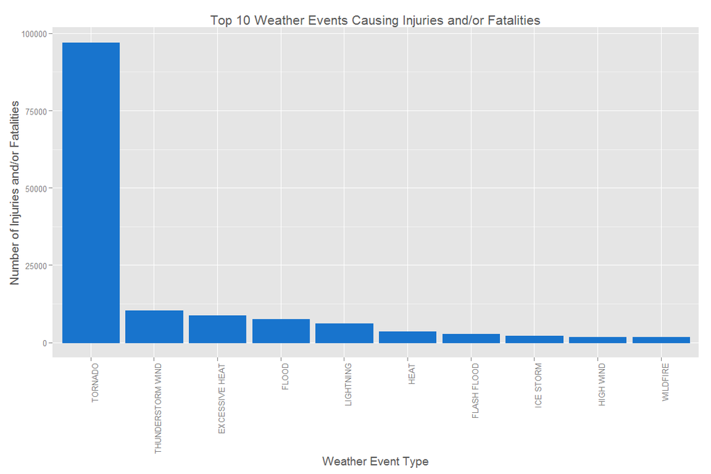

```r
# summarize the data by event type
sdh <- ddply(sd, c("EVTYPE"), summarize, INJ_FAT = sum(INJURIES + FATALITIES))

# remove any items where no one was injured or killed
sdh <- subset(sdh, sdh$INJ_FAT != 0)

# clean up remaining event types
sdh$EVTYPE <- clean.EVTYPE(sdh$EVTYPE)

# resummarize on cleaned up event types
sdh <- ddply(sdh, c("EVTYPE"), summarize, INJ_FAT = sum(INJ_FAT))

# grab top 10 event types
sdh_10 <- head(sdh[with(sdh, order(-INJ_FAT, EVTYPE)),], 10)

# plot them
ggplot(sdh_10,
       aes(reorder(x=factor(EVTYPE),
                   -INJ_FAT
                   ),
           y=INJ_FAT
           )
       ) +
        geom_bar(stat="identity",
                 colour = "dodgerblue3",
                 fill = "dodgerblue3") +
        theme(axis.text.x = element_text(angle= 90,
                                         hjust = 1)
              ) +
        labs(title = "Top 10 Weather Events Causing Injuries and/or Fatalities",
             x = "Weather Event Type",
             y = "Number of Injuries and/or Fatalities") +
        mytheme
```

By far, the type of weather event that has caused the most injuries and fatalities over the given time period is Tornadoes.

### Ecomnomic Impact

The weather events that are the most impactful economically are the ones that cause the most property and crop damage (in dollars) combined.

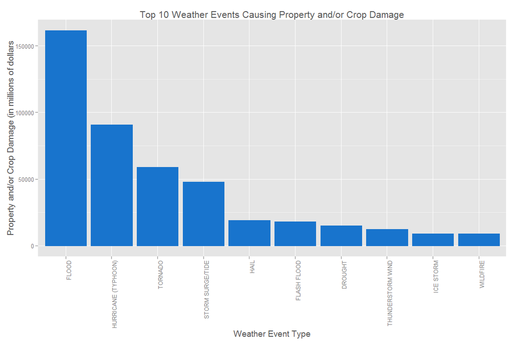

```r
# start pulling out just the needed columns
sde <- subset(sd, select=c(EVTYPE, PROPDMG, PROPDMGEXP, CROPDMG, CROPDMGEXP))

# normalize the multipliers
sde$PROPDMGEXP <- toupper(sde$PROPDMGEXP)
sde$CROPDMGEXP <- toupper(sde$CROPDMGEXP)

# these are the only defined multipliers
valid_EXP <- data.frame(cbind(EXP_values = c("K", "M", "B"), EXP_mulitpliers = c(10^3, 10^6, 10^9)))

# this query pulls in the multiplier value
sql.1 <- "select EVTYPE, ((PROPDMG * COALESCE(PEXP.EXP_mulitpliers, 0)) + (CROPDMG * COALESCE(CEXP.EXP_mulitpliers, 0))) TOTAL_DMG"
sql.1 <- paste(sql.1, " from sde left outer join valid_EXP PEXP on sde.PROPDMGEXP = PEXP.EXP_values")
sql.1 <- paste(sql.1, " left outer join valid_EXP CEXP on sde.CROPDMGEXP = CEXP.EXP_values")

sde <- sqldf(sql.1)

# remove any items where no damage was calculated
sde <- subset(sde, sde$TOTAL_DMG > 0)

# clean up remaining event types
sde$EVTYPE <- clean.EVTYPE(sde$EVTYPE)

# summarize the data by the normalized event types
sde <- ddply(sde, c("EVTYPE"), summarize, TOTAL_DMG = sum(TOTAL_DMG))

# grab top 10 event types
sde_10 <- head(sde[with(sde, order(-TOTAL_DMG, EVTYPE)),], 10)

# plot them
ggplot(sde_10,
       aes(reorder(x=factor(EVTYPE),
                   -TOTAL_DMG
                   ),
           y=TOTAL_DMG/10^6
           )
       ) +
        geom_bar(stat="identity",
                 colour = "dodgerblue3",
                 fill = "dodgerblue3") +
        theme(axis.text.x = element_text(angle= 90,
                                         hjust = 1)
              ) +
        labs(title = "Top 10 Weather Events Causing Property and/or Crop Damage",
             x = "Weather Event Type",
             y = "Property and/or Crop Damage (in millions of dollars") +
        mytheme
```

The type of weather event that has caused the most property damage and / or crop damage over the given time period is Floods.